# Series de tiempo y redes recurrentes

Técnicas de Aprendizaje de Máquina

Oscar Bustos

## Una serie también cabe en una tabla

Para estimar **los alquileres de la siguiente hora**:

1. Cada hora de destino se convierte en una fila.
2. El pasado y el calendario forman las variables.
3. Una regresión o un ensamble predice la demanda.
4. Evaluamos en horas posteriores al entrenamiento.

Después cambiaremos la representación de ese pasado para introducir una **RNN**.

## Predecimos con el pasado

$$\widehat y_t=f(y_{t-1},y_{t-2},\ldots,c_t)$$

- **Objetivo $y_t$:** alquileres durante la hora $t$.
- **Origen:** final de la hora $t-1$.
- **Horizonte:** una hora.
- **Calendario $c_t$:** hora y día de destino, ya conocidos.

## La demanda sigue ciclos semanales

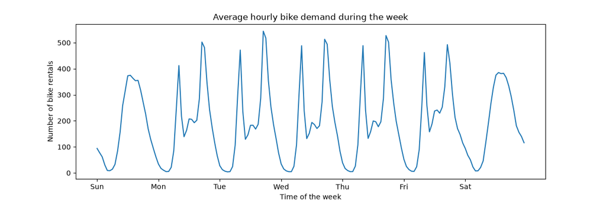

Los días laborales presentan picos de desplazamiento distintos al fin de semana.

Figura oficial de scikit-learn, Bike Sharing Demand, BSD-3-Clause (scikit-learn developers, s. f.-b).

## Los patrones conviven con el ruido

| Componente | Ejemplo en demanda |
| --- | --- |
| Tendencia | Un cambio sostenido del nivel de uso |
| Estacionalidad | Repetición diaria o semanal |
| Variación no explicada | Eventos o factores que faltan |

Una misma hora del calendario puede tener demandas distintas.

Adaptación conceptual del capítulo 15 (Géron 2022).

## Solo usamos lo que ya conocemos

| Variable para predecir $y_t$ | ¿Disponible al final de $t-1$? |
| --- | --- |
| Alquileres en $t-1$ | Sí, si ya llegaron los datos |
| Hora y festivo de $t$ | Sí, con calendario conocido |
| Temperatura observada en $t$ | Todavía no |
| Pronóstico del clima para $t$ | Sí, si ya estaba emitido |

La disponibilidad se comprueba en el **origen del pronóstico**.

## Cada fila resume un pasado distinto

Serie didáctica por hora: **40, 55, 70, 90, 80** alquileres.

| Hora objetivo | $y_{t-3}$ | $y_{t-2}$ | $y_{t-1}$ | $y_t$ |
| --- | --- | --- | --- | --- |
| 09:00 | 40 | 55 | 70 | **90** |
| 10:00 | 55 | 70 | 90 | **80** |

Las columnas históricas forman $X$. La última columna es el objetivo.

## Un rezago exige una rejilla regular

Entrada: `df` con índice temporal y columna `count`.

```python
y = df["count"].sort_index()
assert y.index.is_unique
y = y.asfreq("h")
horas_sin_dato = y[y.isna()].index
```

- `shift(24)` desplaza **24 filas**.
- La rejilla horaria permite identificar horas ausentes.
- Una hora sin registro no significa demanda cero.

## Los rezagos aportan varias escalas

```python
tab = y.to_frame("objetivo")
for k in [1, 2, 3, 24, 168]:
    tab[f"lag_{k}"] = y.shift(k)
```

| Rezago | Información candidata |
| --- | --- |
| 1, 2, 3 horas | Dinámica reciente |
| 24 horas | Misma hora del día anterior |
| 168 horas | Misma hora de la semana anterior |

Adaptación a pandas del ejemplo oficial escrito en Polars (scikit-learn developers, s. f.-a).

## La media móvil termina en el pasado

$$m_t=\frac{1}{24}\sum_{j=1}^{24}y_{t-j}$$

```python
tab["media_24h"] = y.shift(1).rolling(24).mean()
```

- `shift(1)` deja a $y_t$ fuera de la ventana.
- `rolling(24)` resume las últimas 24 horas observadas.
- Una ventana centrada incluiría observaciones futuras.

Estadísticas móviles adaptadas de (scikit-learn developers, s. f.-a).

## ¿Cuál variable conoce el futuro?

Queremos predecir `y[t]` al final de la hora anterior.

| Opción | Variable |
| --- | --- |
| A | `y.shift(1)` |
| B | `y.rolling(24).mean()` |
| C | `y.index.hour` |

**B incluye `y[t]`**, que todavía no observamos.

## El calendario está disponible

```python
tab["hora"] = tab.index.hour
tab["dia_semana"] = tab.index.dayofweek
```

- La hora describe la posición dentro del día.
- El día de semana distingue rutinas semanales.
- Un calendario local añade festivos conocidos.

La hora pico puede depender de que el día sea **laboral**.

## La hora ordinal limita al modelo

Con un único término lineal: $\widehat y=b+w\,\text{hora}$.

- Una pendiente no representa dos picos diarios.
- Las horas 23 y 0 quedan lejos numéricamente.
- **One-hot** permite un coeficiente por categoría.

```python
from sklearn.preprocessing import OneHotEncoder
horas = OneHotEncoder(handle_unknown="ignore")
```

Comparación de representaciones del calendario (scikit-learn developers, s. f.-b).

## Seno y coseno cierran el ciclo

$$s_t=\sin(2\pi\,\text{hora}_t/24)$$
$$q_t=\cos(2\pi\,\text{hora}_t/24)$$

Las horas 23 y 0 quedan próximas.

Un solo par puede resultar rígido para varios picos.

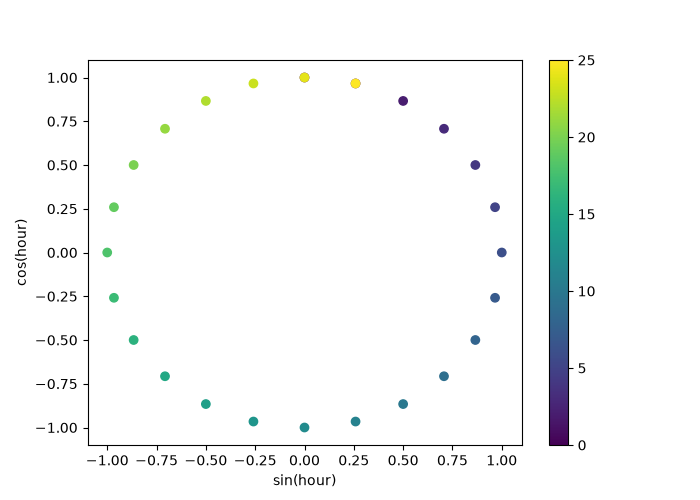

Figura oficial de scikit-learn, BSD-3-Clause (scikit-learn developers, s. f.-b).

## Los splines permiten picos locales

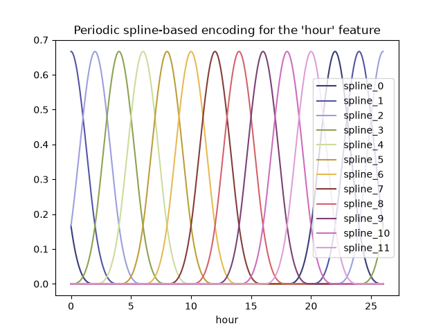

Cada base cubre parte del día.

La regresión aprende su peso.

La opción **periódica** une los extremos.

`SplineTransformer(extrapolation="periodic")`. Figura oficial, BSD-3-Clause (scikit-learn developers, s. f.-b).

## Las bases fijan la comparación

| Referencia | Pronóstico de $y_t$ |
| --- | --- |
| Persistencia | $\widehat y_t=y_{t-1}$ |
| Estacional diaria | $\widehat y_t=y_{t-24}$ |
| Estacional semanal | $\widehat y_t=y_{t-168}$ |

¿El modelo mejora estas referencias en **las mismas horas**?

Referencias ingenuas y estacionales (Géron 2022).

## Ridge combina señales regularizadas

$$\widehat y_t=b+\sum_j w_j x_{t,j}$$

```python
from sklearn.pipeline import make_pipeline
from sklearn.preprocessing import StandardScaler
from sklearn.linear_model import Ridge
lineal = make_pipeline(
    StandardScaler(), Ridge(alpha=1.0)
)
```

El escalado y los pesos se ajustan **solo con entrenamiento**.

## Los árboles aprenden interacciones

```python
from sklearn.ensemble import HistGradientBoostingRegressor
arboles = HistGradientBoostingRegressor(
    max_iter=100, max_leaf_nodes=15,
    early_stopping=False, random_state=42
)
```

- Los cortes pueden combinar hora y día de semana.
- Los árboles no necesitan estandarización.
- La complejidad se elige con validación temporal.

Gradient boosting con rezagos (scikit-learn developers, s. f.-a).

## La codificación cambia el pronóstico

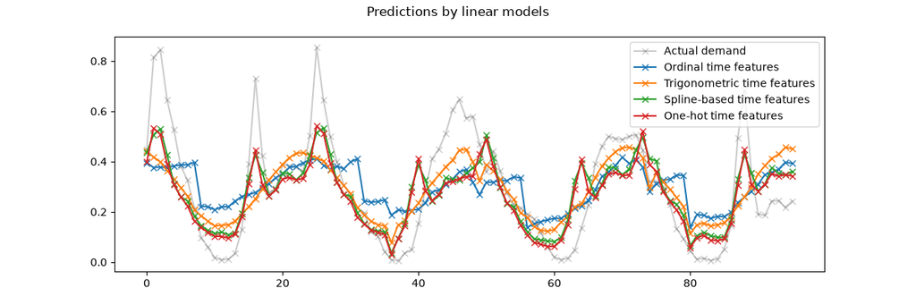

Splines y one-hot siguen mejor algunos picos, pero aún faltan interacciones.

Resultado publicado, demanda normalizada. Figura oficial, BSD-3-Clause (scikit-learn developers, s. f.-b).

## El entrenamiento precede a la prueba

| Periodo | Uso |
| --- | --- |
| Pasado inicial | Ajustar transformaciones y modelo |
| Periodo siguiente | Seleccionar variables e hiperparámetros |
| Pasado más reciente | Prueba final reservada |

- El reparto aleatorio puede mezclar pasado y futuro.
- La dependencia temporal cambia cómo evaluamos.

Evaluación de pronósticos (scikit-learn developers, s. f.-a; Géron 2022).

## Cada corte simula un nuevo origen

```python
from sklearn.model_selection import TimeSeriesSplit
datos = tab.dropna()
X = datos.drop(columns="objetivo")
y_obj = datos["objetivo"]
cv = TimeSeriesSplit(n_splits=3, test_size=168, gap=0)
for idx_tr, idx_va in cv.split(X):
    lineal.fit(X.iloc[idx_tr], y_obj.iloc[idx_tr])
    pred = lineal.predict(X.iloc[idx_va])
```

Cada bloque de validación contiene una semana horaria.

## El origen fija el pasado disponible

| Protocolo | Para pronosticar la segunda hora |
| --- | --- |
| Un paso, origen actualizado | Ya observamos la primera hora |
| Varias horas, origen fijo | La primera hora sigue siendo futura |

- Un rezago observado en prueba sirve en el primer caso.
- En origen fijo exige un pronóstico o un modelo directo.
- El `gap` responde al horizonte y a demoras de las etiquetas.

## MAE mide errores en alquileres

$$\mathrm{MAE}=\frac{1}{n}\sum_{i=1}^n|y_i-\widehat y_i|$$

$$\mathrm{RMSE}=\sqrt{\frac{1}{n}\sum_{i=1}^n(y_i-\widehat y_i)^2}$$

- Ambas se expresan en alquileres por hora.
- RMSE da más peso a errores grandes.
- MAPE divide por la demanda y se complica cerca de cero.

## La prueba compara tareas iguales

- Mismos orígenes, horizonte y horas evaluadas.
- Misma información disponible al pronosticar.
- Transformaciones aprendidas dentro de cada corte.
- Selección del modelo antes de abrir la prueba final.
- Errores comparados con persistencia y estacionalidad.

Una arquitectura más compleja debe **demostrar su utilidad**.

## La ventana también es una secuencia

Para el objetivo de las 09:00, usamos **40, 55, 70**.

| Representación | Una muestra |
| --- | --- |
| Tabla, columnas por rezago | `[40, 55, 70]` |
| Secuencia, pasos con una variable | `[[40], [55], [70]]` |

Mismo pasado. En la secuencia, **cada fila interna es una hora**.

## ¿Qué forma recibe una RNN?

Dos ventanas, tres horas por ventana, una variable por hora:

```python
import numpy as np
ventanas = np.array([[[40], [55], [70]],
                     [[55], [70], [90]]])
```

¿Cuál es la forma de `ventanas`?

**`(2, 3, 1)` = (muestras, pasos temporales, variables)**.

## El lote reúne ventanas consecutivas

```python
valores = y.to_numpy(dtype="float32")[:, None]
T = 24
X_seq = np.stack([
    valores[t-T:t] for t in range(T, len(valores))
])
y_seq = valores[T:, 0]
```

`X_seq`: **(N − 24, 24, 1)**. `y_seq`: **(N − 24,)**.

Cada ventana termina una hora antes de su objetivo.

## El estado resume lo observado

$$h_j=\tanh(W_x x_j+W_h h_{j-1}+b_h)$$

$$\widehat y_t=w_o^\top h_T+b_o$$

- $x_j$: observación del paso $j$ dentro de la ventana.
- $h_j$: estado oculto después de leer ese paso.
- Leemos del pasado al presente, con $h_0=0$.

Celda recurrente y lectura final, adaptadas de (Géron 2022).

## Los pesos se comparten en el tiempo

| Paso | Entrada | Estado calculado | Parámetros |
| --- | --- | --- | --- |
| 1 | $x_1$ | $h_1=f(x_1,0)$ | $W_x,W_h,b_h$ |
| 2 | $x_2$ | $h_2=f(x_2,h_1)$ | Los mismos |
| 3 | $x_3$ | $h_3=f(x_3,h_2)$ | Los mismos |

Aumentar los pasos **no añade una matriz nueva por hora**.

## El estado cambia con cada entrada

Ejemplo escalar: $h_j=\tanh(0.5x_j+0.5h_{j-1})$, $h_0=0$.

| Paso | $x_j$ | $h_{j-1}$ | $h_j$ aproximado |
| --- | --- | --- | --- |
| 1 | 0 | 0 | 0 |
| 2 | 1 | 0 | 0.462 |
| 3 | 0 | 0.462 | 0.227 |

En el tercer paso, la entrada es cero y **persiste parte del pasado**.

## Una salida resume toda la ventana

```python
import tensorflow as tf
model = tf.keras.Sequential([
    tf.keras.layers.Input(shape=(24, 1)),
    tf.keras.layers.SimpleRNN(16, activation="tanh",
                             stateful=False),
    tf.keras.layers.Dense(1)
])
```

`SimpleRNN` entrega el estado final. `Dense(1)` predice $y_t$.

Interfaz oficial de `SimpleRNN` (TensorFlow, s. f.).

## Cada ventana reinicia el estado

| Muestra | Entrada | Estado al comenzar |
| --- | --- | --- |
| Objetivo $y_t$ | $y_{t-24},\ldots,y_{t-1}$ | $h_0=0$ |
| Objetivo $y_{t+1}$ | $y_{t-23},\ldots,y_t$ | $h_0=0$ |

- Con `stateful=False`, el estado no pasa al siguiente lote.
- La memoria se reconstruye dentro de cada ventana.

Semántica del estado recurrente (TensorFlow, s. f.).

## BPTT reúne gradientes de cada paso

1. La pasada hacia adelante calcula $h_1,\ldots,h_T$.
2. La pérdida compara $\widehat y_t$ con $y_t$.
3. El gradiente recorre las operaciones de la ventana.
4. Se suman las contribuciones a los pesos compartidos.
5. El optimizador realiza una actualización por lote.

**Backpropagation through time** usa la misma regla de la cadena.

Entrenamiento de redes recurrentes (Géron 2022).

## La RNN aprende con ventanas

Entrada: ventanas separadas por fecha del objetivo y escaladas con entrenamiento.

```python
model.compile(optimizer="adam", loss="mse", metrics=["mae"])
model.fit(
    X_train_seq, y_train_seq,
    validation_data=(X_val_seq, y_val_seq),
    epochs=30, batch_size=32, shuffle=True
)
```

El orden **dentro de cada ventana** se conserva.

## La memoria útil puede ser corta

- Repetir transformaciones puede diluir información.
- Los gradientes pueden desaparecer o crecer demasiado.
- Ventanas largas elevan el costo del entrenamiento.
- El estado resume el pasado con capacidad limitada.

LSTM y GRU amplían las opciones para una clase posterior.

Limitaciones de las RNN simples (Géron 2022).

## La RNN también necesita validación

- Comparar con las bases y los modelos tabulares.
- Ofrecer la misma información a todos los modelos.
- Deshacer el escalado antes de medir alquileres.
- Revisar error en horas pico y periodos posteriores.
- Medir costo de entrenamiento y de inferencia.

Una RNN pequeña puede ejecutarse en **CPU**.

## Los datos y el costo guían la elección

| Criterio | Modelo tabular | RNN básica |
| --- | --- | --- |
| Representación | Rezagos y resúmenes | Secuencia y estado aprendido |
| Contexto observado | Variables construidas | Ventana de entrada elegida |
| Interacciones | Explícitas o aprendidas | Transformaciones recurrentes |
| Costo | Medir según el modelo | Crece con pasos y estado |
| Evidencia necesaria | Validación temporal | La misma validación temporal |

La elección depende del resultado y del uso previsto.

## El escenario cambia la decisión

**Caso A:** seis meses horarios de una ciudad, pronóstico de una hora y CPU.

**Caso B:** muchas ciudades, historias extensas y dinámica compartida.

Para cada caso:

1. Propón una base y un modelo candidato.
2. Define qué datos estarán disponibles al pronosticar.
3. Explica qué resultado justificaría usar una RNN.

## Ticket de salida

1. ¿Por qué desplazar una media móvil antes de usarla?
2. ¿Qué representa cada eje de **(32, 24, 1)**?
3. ¿Qué comparten los pasos de una misma RNN?
4. ¿Cómo demostrarías que mejora una base estacional?

## Referencias

Géron, Aurélien. 2022. *Hands-On Machine Learning with Scikit-Learn, Keras, and TensorFlow*. 3.ª ed. O’Reilly Media.

*Predicción de series de tiempo: del ML clásico a las redes neuronales recurrentes*. s. f.

scikit-learn developers. s. f.-a. «Lagged features for time series forecasting». Accedido 26 de octubre de 2026. https://scikit-learn.org/stable/auto_examples/applications/plot_time_series_lagged_features.html.

scikit-learn developers. s. f.-b. «Time-related feature engineering». Accedido 26 de octubre de 2026. https://scikit-learn.org/stable/auto_examples/applications/plot_cyclical_feature_engineering.html.

TensorFlow. s. f. «tf.keras.layers.SimpleRNN». Accedido 26 de octubre de 2026. https://www.tensorflow.org/api_docs/python/tf/keras/layers/SimpleRNN.